# Data Handling & Analysis 1

## BD7054

## 2016-2017

### Andrew Jackson

### Zoology, School of Natural Sciences

### a.jackson@tcd.ie

### Adam Kane

### University College Cork

### adam.kane@ucc.ie

# Week 2 - Revision of course

#### There are two broad types of plots scatter plots and box plots

#### Here are some data on the body mass and brain mass of various mammals and birds.

#### We’ve also created a new variable, the ratio of brain mass to body mass.

|  | species | class | brain | body | ratio |
| --- | --- | --- | --- | --- | --- |
| 1 | Human | Mammalia | 1400.0 | 62000 | 0.022580645 |
| 2 | New Caledonian Crow | Aves | 7.5 | 277 | 0.027075812 |
| 3 | African elephant | Mammalia | 6000.0 | 5000000 | 0.001200000 |
| 4 | Common Bottlenose Dolphin | Mammalia | 1700.0 | 160000 | 0.010625000 |
| 5 | Emperor Penguin | Aves | 46.2 | 28000 | 0.001650000 |
| 6 | Little Penguin | Aves | 7.4 | 960 | 0.007708333 |

# Calculate a new response variable

#### We could set up a question with class as an explanatory variable and the ratio as the response variable.

```r
data[,c("species","class","ratio")]
```

| species | class | ratio |
| --- | --- | --- |
| Human | Mammalia | 0.022580645 |
| New Caledonian Crow | Aves | 0.027075812 |
| African elephant | Mammalia | 0.001200000 |
| Common Bottlenose Dolphin | Mammalia | 0.010625000 |
| Emperor Penguin | Aves | 0.001650000 |
| Little Penguin | Aves | 0.007708333 |
| Rat | Mammalia | 0.015000000 |
| Blue Whale | Mammalia | 0.000100000 |
| Sperm Whale | Mammalia | 0.000211351 |
| Rabbit | Mammalia | 0.004800000 |

[output cut: 63 more lines]

# Boxplots

#### Typically a question like that is answered by comparing the means between the groups.

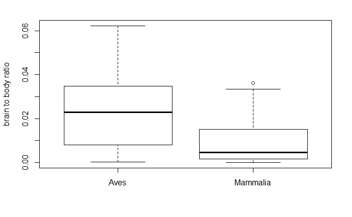

```r
boxplot(data$ratio~data$class, ylab="brain to body ratio")
```

# Alternative Question

#### An alternative question would be to have brain mass as a response variable and body mass as the explanatory variable.

```r
data[,c("species","brain","body")]
```

| species | brain | body |
| --- | --- | --- |
| Human | 1400.000 | 6.2000e+04 |
| New Caledonian Crow | 7.500 | 2.7700e+02 |
| African elephant | 6000.000 | 5.0000e+06 |
| Common Bottlenose Dolphin | 1700.000 | 1.6000e+05 |
| Emperor Penguin | 46.200 | 2.8000e+04 |
| Little Penguin | 7.400 | 9.6000e+02 |
| Rat | 3.000 | 2.0000e+02 |
| Blue Whale | 6000.000 | 6.0000e+07 |
| Sperm Whale | 7820.000 | 3.7000e+07 |
| Rabbit | 12.000 | 2.5000e+03 |

[output cut: 63 more lines]

# Scatterplots

#### Typically the question here is whether the slope differs from zero. Though it could equally be whether it differs from any number, e.g. one in this case if testing for isometric growth

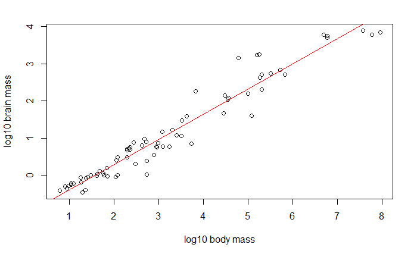

```r
plot(log10(data$body),log10(data$brain),xlab = "log10 body mass", ylab = "log10 brain mass")
fit<-lm(log10(data$brain)~log10(data$body))
abline(fit,col="red")
```

# A Richer Question

#### A richer question might be to have two explanatory variables in body mass AND class for our response variable of brain mass

```r
data[,c("species","brain","body","class")]
```

| species | brain | body | class |
| --- | --- | --- | --- |
| Human | 1400.000 | 6.2000e+04 | Mammalia |
| New Caledonian Crow | 7.500 | 2.7700e+02 | Aves |
| African elephant | 6000.000 | 5.0000e+06 | Mammalia |
| Common Bottlenose Dolphin | 1700.000 | 1.6000e+05 | Mammalia |
| Emperor Penguin | 46.200 | 2.8000e+04 | Aves |
| Little Penguin | 7.400 | 9.6000e+02 | Aves |
| Rat | 3.000 | 2.0000e+02 | Mammalia |
| Blue Whale | 6000.000 | 6.0000e+07 | Mammalia |
| Sperm Whale | 7820.000 | 3.7000e+07 | Mammalia |
| Rabbit | 12.000 | 2.5000e+03 | Mammalia |

[output cut: 63 more lines]

# Scatter plots with colour / shapes

#### Now the question is whether the two categorical groups behave differently. That is, are their lines the same or different?

#### 1. Parallel lines with same slope and different intercept or

#### 2. Different slopes

#### We’d look at this using scatter plots with different colours / shapes for the different classes

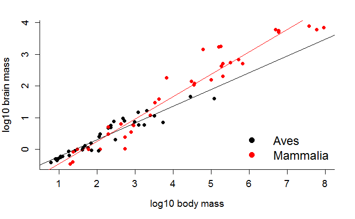

# p-values

#### We need a way to make quantitative, objective statements about our data. To do this we use p-values: the probability of observing our data, *or more extreme*, given the null hypothesis.

# Focus on scatter plots

#### The question is whether our line is significantly different from zero

#### Our null hypothesis is that the line has slope = 0.

#### Our data certainly don’t look like they came from a model with slope forced = 0

#### Therefore our data are unlikely given the null hypothesis

#### How unlikely? We need a probability value

# Simulate our null hypothesis

# P-value for our slope

#### How likely is the “extreme” slope that we observed given the stochasticity (randomness) of our null hypothesis?

#### Given a distribution of slopes possible under the null hypothesis, we can calculate the probability of our observed slope

#### We need also to consider “more extreme” slopes in this calculation and this results in a p-value

#### If p-value is less than 0.05, then we generally reject the null hypothesis

#### That is, there is a 1 in 20 chance that our observed value is generated by our null model

# Summary

#### Science is about constructing experiments or designing observations to test your ideas about how the world works

#### Hypotheses must be falsifiable

#### Generally we construct null hypotheses against which our alternative hypotheses can be tested

#### p-values tell us how likely it is our data came from the null hypothesis and therefore allow us to accept or reject it (H0)

# Introduction to Hypothesis Testing

#### An experiment flipping coins

# A simple experiment

#### Question:

#### -Does adding weight to a coin make it unfair?

#### -Blu-tac added to head side

#### We need to construct testable hypotheses

#### -The null hypothesis

# Weighted coin toss

#### Toss the coin 10 times

#### What is the hypothesis about how you think your system will behave?

#### -More likely to get heads

#### -Less likely to get heads

#### -Either more or less likely to get heads

#### What are the corresponding null hypotheses?

#### -That the coin is fair

# Behaviour of a fair coin

#### The model is a fair 50:50 coin

#### How do we generate information about how a fair coin behaves?

#### -Toss an un-weighted coin 10 times and repeat

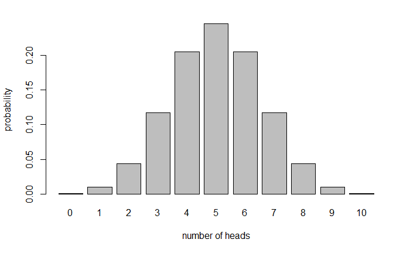

# Behaviour of weighted coin

#### Compare the weighted coin against the expected behaviour of a fair coin

#### Question

#### -How likely is it that our observed coin is fair?

# Alternative hypothesis

#### HA: coin is more likely to produce heads

#### -One-tailed test in right tail

#### HA: coin is less likely to produce heads

#### -One-tailed test in left tail

#### HA: coin is unfair (in either direction)

#### -Two-tailed test including both left and right tails

# P-values

#### A p-value is the probability of your observed data or more extreme being generated according to the null hypothesis

#### The less likely your data are, the less likely you would accept the null hypothesis as being true

#### We generally use a cut-off of p<0.05 to accept the alternative hypothesis

#### One or two tailed tests refer to where you predict your alternative hypotheses to lie before you do your experiment

#### If we flip out coin 10 times and it comes up heads 9 times the p-value we get is 0.02148 which is much less than the 0.05 cutoff that is usually selected. So this would mean our data are inconsistent with the null hypothesis that the coin is fair.

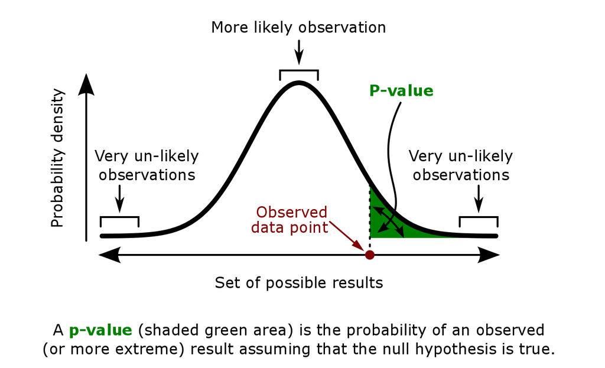

# Summary

#### Science is about constructing experiments or designing observations to test your ideas about how the world works

#### Hypotheses must be falsifiable

#### Generally we construct null hypotheses against which our alternative hypotheses can be tested

#### p-values tell us how likely it is our data came from the null hypothesis and therefore allow us to accept or reject it (H0)

# Regression

#### A regression is a statistical analysis used to predict scores on an outcome variable, based on scores on one or multiple predictor variables, a simple regression has one predictor variable and a multiple regression has multiple predictor variables

# Regression equation

$$Y = B_0 +B_1X_1 + e$$

#### Y = a linear function of $X_1$

#### $B_0$ = intercept = regression constant

#### $B_1$ = slope = regression coefficient

#### e = residual error

# Simple regression example

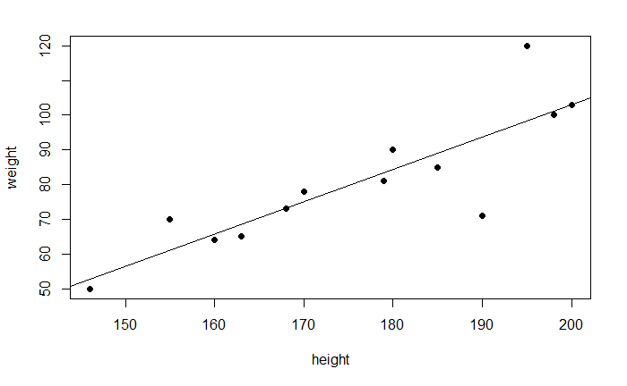

```r
height <- c(163, 185, 155, 195, 168, 198, 200, 146, 179, 160, 180, 170, 190)
weight <- c(65, 85, 70, 120, 73, 100, 103, 50, 81, 64, 90, 78, 71)
plot(weight~height,pch=16)
m1<-lm(weight~height)
abline(m1)
```

```r
print(m1)
```

```
Call:
lm(formula = weight ~ height)

Coefficients:
(Intercept)       height
   -83.2047       0.9313
```

#### Thus the regression equation is therefore

### $Y=-83.2047+0.9313(X)$

#### or weight = -83.2047 + 0.9313(height)

#### What this means is that for with every one unit increase in X there is a 0.9313 increase in Y.

#### In our case it means for every cm increase in height there is a 0.9313 kg increase in weight

#### The estimate of the intercept is -83.2047, is the predicted score on Y when X = 0.

#### But that doesn’t make a lot of sense here because it would mean a person who has a height of 0 cm is predicted to weigh -83 kg.

# ANOVA - Analysis of Variance

#### Instead of fitting continuous, measured variables to data (as in regression), many experiments involve exposing experimental material to a range of discrete levels of one or more categorical variables known as factors.

#### The data here are from an agricultural experiment in which six different insect sprays were tested in many different fields, and the response variable was a count of insects found in each field after spraying.

#### It is important to understand that regression and analysis of variance (ANOVA) are identical approaches except for the nature of the explanatory variables.

```
            Df Sum Sq Mean Sq F value Pr(>F)
spray        5   2669   533.8    34.7 <2e-16 ***
Residuals   66   1015    15.4
---
Signif. codes:  0 *** 0.001 ** 0.01 * 0.05 . 0.1   1
```

# Generalised Linear Models

## - Regression with more than one line

# Focus on gene / environment effects

#### Growth rates are affected by extrinsic environmental conditions

#### Growth rates are also affected by intrinsic physiological factors which may be governed by genetic factors

# Experiment

#### -Rear larval oysters at different temperatures

#### -Record simple growth rate as mm/week

#### -Repeat the experiment with different genotypes

# The effect of temperature

#### This is a simple linear regression where the intercept is 5 and the slope is 1.3

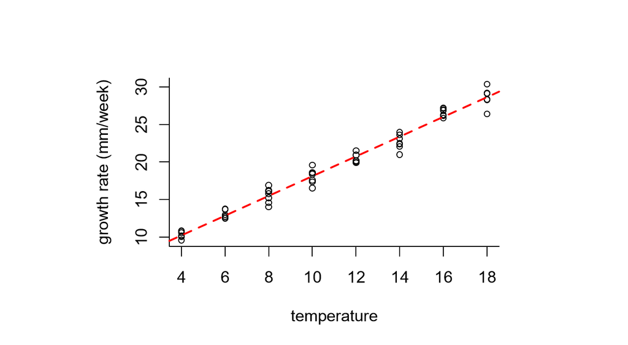

# The effect of genotype

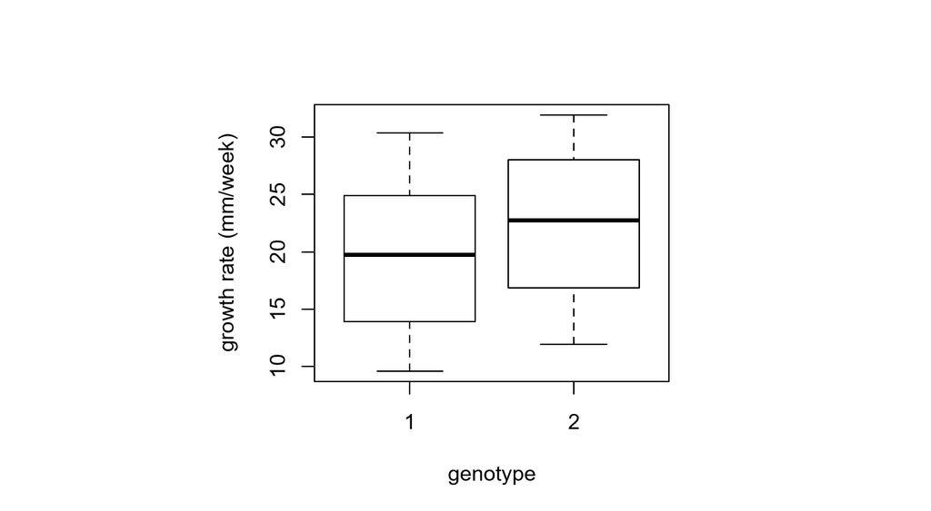

# The effect of both genotype AND temperature

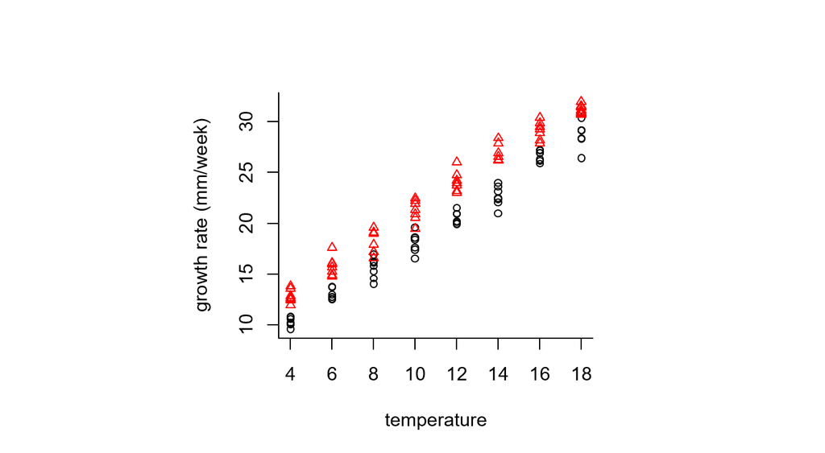

# How do these lines differ?

#### Temperature affects both genotypes equally

#### There is a fixed effect of genotype

#### -this effect is constant for all temperatures

#### The red genotype grows faster than the black one

#### coefficients

#### -Slopes = 1.3

#### -red intercept = 8

#### -black intercept=5

# A different genotype

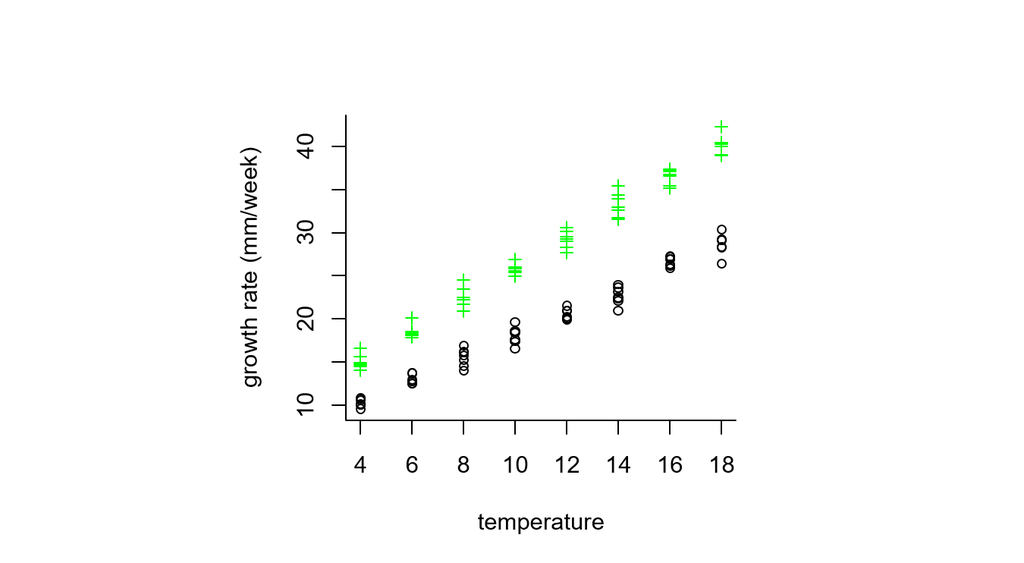

# How do these lines differ?

#### There is still an effect of temperature

#### But, now it is different for each genotype

#### The effect of genotype is no longer fixed for all temperatures

#### There is an interaction between temperature (environment) and genotype

#### Coefficients

#### -Green slope = 1.8

#### -Green intercept = 8

#### -Black slope = 1.3

#### -Black intercept = 5

# A slightly different question

#### And why its important to consider the linear covariate when comparing between groups

# How do we compare two lines statistically?

#### Known as:

#### Analysis of Covariance (ANCOVA) aka a GLM with fixed factors and linear covariates

#### ANCOVA combines elements from regression and analysis of variance. The response variable is continuous, and there is at least one continuous explanatory variable and at least one categorical explanatory variable.

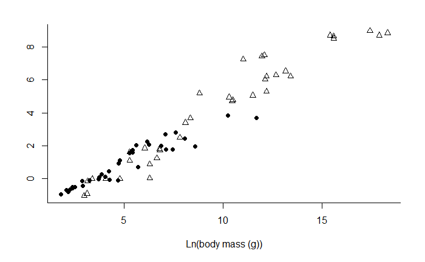

# An alternative dataset

#### Experiment to study the effect of herbivores on primary productivity in ecosystems

#### Series of in situ exclusion experiments

#### Measured:

#### -fruit production mass (g)

#### -Grazed / Ungrazed

#### -Root diameter at start of experiment.

|  | Root | Fruit | Grazing |
| --- | --- | --- | --- |
| 1 | 6.225 | 59.77 | Ungrazed |
| 2 | 6.487 | 60.98 | Ungrazed |
| 3 | 4.919 | 14.73 | Ungrazed |
| 4 | 5.130 | 19.28 | Ungrazed |
| 5 | 5.417 | 34.25 | Ungrazed |
| 6 | 5.359 | 35.53 | Ungrazed |

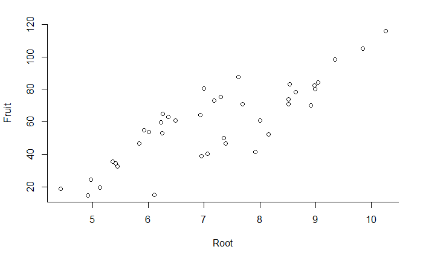

# The Data

```r
head(growth)
```

|  | Root | Fruit | Grazing |
| --- | --- | --- | --- |
| 1 | 6.225 | 59.77 | Ungrazed |
| 2 | 6.487 | 60.98 | Ungrazed |
| 3 | 4.919 | 14.73 | Ungrazed |
| 4 | 5.130 | 19.28 | Ungrazed |
| 5 | 5.417 | 34.25 | Ungrazed |
| 6 | 5.359 | 35.53 | Ungrazed |

#### Here, the response variable is Fruit, and we have two explanatory variables in Root and Grazing. Root is continuous whereas Grazing is a factor with two levels.

# Questions to ask

#### How does grazing affect seed production?

#### -Our expectation is that big plants will produce more seeds than small plants

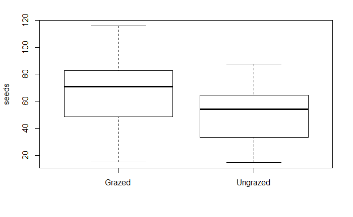

#### This result looks counter-intuitive because it shows that the plants that were grazed on by herbivores produced MORE seeds not less than the ungrazed plants!

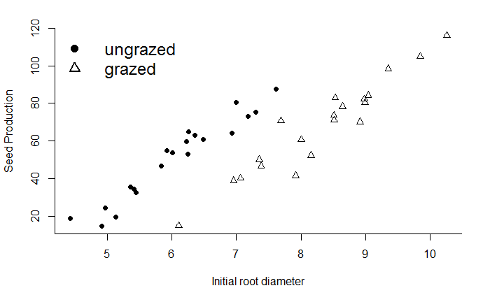

#### Why was root diameter recorded?

#### This was recorded because initial plant size was thought likely to influence fruit production.

#### -How might this have changed the picture if it were omitted?

#### Different sized plants were allocated to the two treatments.

#### The grazed plants were bigger at the outset.

#### If you compare like with like (e.g. plants at 7mm initial root diameter) it is clear that the ungrazed plants produced more seed than the grazed plants.

# Creating an ANCOVA model

#### For ANCOVA, the most complicated model has different slopes and intercepts for each level of the factor.

#### Here we have a two-level factor (Grazed and Ungrazed) and we are fitting a linear model with two parameters $y=B_0+B_1X_1$ so the most complicated mode has four parameters (two slopes and two intercepts).

# Testing non-parallel lines

#### To fit different slopes and intercepts we use the asterisk $*$ notation:

#### In R we do this as follows:

```r
model1<-glm(Fruit~Root*Grazing,data=growth)
summary(model1)
```

```
Call:
glm(formula = Fruit ~ Root * Grazing, data = growth)

Deviance Residuals:
     Min        1Q    Median        3Q       Max
-17.3177   -2.8320    0.1247    3.8511   17.1313

Coefficients:
                     Estimate Std. Error t value Pr(>|t|)
(Intercept)          -125.173     12.811  -9.771 1.15e-11 ***
Root                   23.240      1.531  15.182  < 2e-16 ***
GrazingUngrazed        30.806     16.842   1.829   0.0757 .
Root:GrazingUngrazed    0.756      2.354   0.321   0.7500
---
Signif. codes:  0 *** 0.001 ** 0.01 * 0.05 . 0.1   1

(Dispersion parameter for gaussian family taken to be 46.65692)

    Null deviance: 23743.8  on 39  degrees of freedom
Residual deviance:  1679.6  on 36  degrees of freedom
AIC: 273.01

Number of Fisher Scoring iterations: 2
```

#### This shows that initial root size has a massive effect on fruit production, but there is no indication of any difference in the slope of this relationship between the two grazing treatments (Root:GrazingUngrazed) so we remove it.

# Testing parallel lines

#### We now use $+$ rather than $*$ in the model formula. This says ‘fit different intercepts for grazed and ungrazed plants, but fit the same slope to both graphs’.

```r
model2<-glm(Fruit~Root+Grazing,data=growth)
summary(model2)
```

```
Call:
glm(formula = Fruit ~ Root + Grazing, data = growth)

Deviance Residuals:
     Min        1Q    Median        3Q       Max
-17.1920   -2.8224    0.3223    3.9144   17.3290

Coefficients:
                Estimate Std. Error t value Pr(>|t|)
(Intercept)     -127.829      9.664  -13.23 1.35e-15 ***
Root              23.560      1.149   20.51  < 2e-16 ***
GrazingUngrazed   36.103      3.357   10.75 6.11e-13 ***
---
Signif. codes:  0 *** 0.001 ** 0.01 * 0.05 . 0.1   1

(Dispersion parameter for gaussian family taken to be 45.52598)

    Null deviance: 23743.8  on 39  degrees of freedom
Residual deviance:  1684.5  on 37  degrees of freedom
AIC: 271.13

Number of Fisher Scoring iterations: 2
```

#### You know when you have got a good model, because every row of the coefficients table has one or more significance stars (three in this case, because the effects are all so strong).

# Parameter Estimates Explained

# Adding the lines to our plot

#### We can use these paramaters to fit the two regression lines to our data.

#### For grazed the line is $-127.829+23.56(X)$

#### For the ungrazed line it is $-127.829+36.103+23.56(X)$

```r
growth<-read.csv("ipomopsis.csv",header = T,sep = ",")
#head(growth)
plot(growth$Fruit~growth$Root,bty="l",pch = c(2, 16)[as.numeric(growth$Grazing)],xlab="Initial root diameter",ylab = "Seed Production")
legend("topleft", c("ungrazed","grazed"), pch= c(16,2), bty="n",cex=1.5,lwd=2,lty=NA)
```

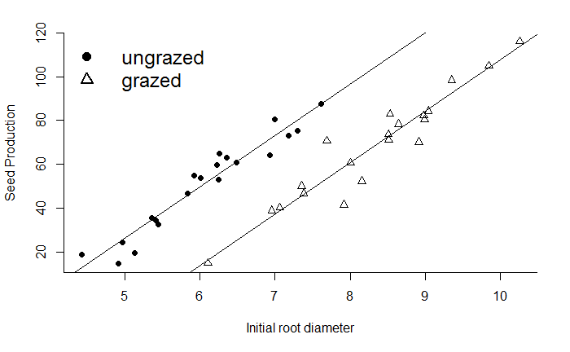

```r
abline(-127.829,23.56)
abline(-127.829+36.103,23.56)
```

# Model Parameters

#### In a linear model with interactions, the mathematical expression for two regressors is:

#### $$\hat Y=\hat\beta_0+\hat\beta_1\,X_1+\hat\beta_2\,X_2+\hat\beta_3\, \color{blue}{X_1*X_2}$$

#### one of the variables $X_2$ is categorical with factors A and B.

#### For instance, it could be the variable gender with values M and F coded as 0 and 1. Variable $X_1$ is a continuous measurement.

#### For males, $(X_2=0)$ $$\color{blue}{X_1*X_2 = X_1\,*\,0 =0}$$ for all male observations

#### We end up with

#### $$\hat Y=\hat\beta_0+\hat\beta_1\,X_1$$

#### , with the intercept being $\hat\beta_0$ and the slope $\hat\beta_1$

#### For females $(X_2=1)$,

#### $$\color{blue}{X_1*X_2 = X_1\,*\,1 =X_1}$$

#### We end up with

#### $$\hat Y=\hat\beta_0+\hat\beta_1\,X_1+\hat\beta_2\,\color{blue}{1}+\hat\beta_3\, \color{blue}{X_1}$$

#### with intercept $\hat\beta_0$ + $\hat\beta_2$ and slope $\hat\beta_1$ + $\hat\beta_3$

#### So notice that for each factor, and due to the interaction, you wind up with different intercepts and different slopes.

#### If there was no interaction, the model would be:

#### $$\hat Y=\hat\beta_0+\hat\beta_1\,X_1+\hat\beta_2\,X_2$$

#### And we would obtain one single slope for both M and F, $\hat\beta_1$ and two different intercepts: $\hat\beta_0$ for M and $\hat\beta_0+ \hat\beta_2$ for F.

#### So the presence of an interaction changes the relationship of the continuous variable $X_1$ with the predicted values (the slope).

# Example with different slopes

```r
dietData<-read.csv("diet.csv",header = T,sep = ",")
head(dietData)
#as.factor(data$diet)
#head(growth)
plot(dietData$weight~dietData$height,bty="l",pch = c(2, 16)[as.numeric(dietData$diet)],xlab="Height",ylab = "Weight")
legend("bottomright", c("diet A","diet B"), pch= c(2,16), bty="n",cex=1.5,lwd=2,lty=NA)
m1<-glm(dietData$weight ~ dietData$height * dietData$diet)
summary(m1)
m2<-glm(dietData$weight ~ dietData$height + dietData$diet)
#summary(m2)
abline(170.1664,-0.3768)
abline(170.1664+(-172.5639), -0.3768+2.4727)
```

[output not shown]

#### The baseline intercept will be $\hat\beta_0$ and the baseline slope will be $\hat\beta_1$.

#### The intercept for the next factor level will be $\hat\beta_0 + \hat\beta_2$ and the slope for the next factor level will be $\hat\beta_1 + \hat\beta_3$

# Comparing Models

#### AIC is a number that is helpful for comparing models as it includes measures of both how well the model fits the data and how complex the model is. The lower the AIC the better. In general a -2 difference in AIC suggests an improvement.

```r
summary(m1)
summary(m2)
```

[output not shown]

# What are interactions?

#### $Y = B0 + B1X1+ B2X2 + B3X1*X2$

#### The interactive effect between X1 and X2 on Y corresponds to the B3 slope. If B3 is reliable (or “statistically significant”), it means that the effect of X1 on Y depends on the level of X2 (or otherwise, but it’s exactly the same, the effect of X2 on Y depends on the level of X1).

#### Y is lifetime (an objectively good thing to have more of)

#### X1 (associated with B1) is the number of cigarettes one smokes per day

#### X2 (associated with B2) is the quantity of alcohol one consumes per day.

#### X1*X2 (associated with B3) is their interaction

#### As smoking has a negative effect on life expectancy (the effect B1 being negative on Y), that means that the more you smoke (as X1 gets more positive), the less you live (Y gets less positive).

#### As the interactive effect of smoking and drinking on life expectancy is negative (the effect of B3 being negative on Y), this means that the more you drink (the more X2 is positive), the more deleterious cigarettes become (B1 becomes more negative). For instance, each smoked cigarette makes you live 2 minutes less as you drink no alcohol, but if you drink one glass of wine per day, each smoked cigarette makes you live 6 minutes less.